# Time Series Analysis of *Aedes albopictus* Eggs

Daniele Da Re, Andrea Radici

2023-07-14

## 0. Introduction

This report presents a time series analysis of *Aedes albopictus* egg abundance using the **VectAbundance dataset** ([Da Re et al., 2024](https://doi.org/10.1038/s41597-024-03482-y)). The study focuses on understanding the influence of climatic variables on egg dynamics, model validation, and climate change projections.

The specific objectives of this study are:

- **Climatic Drivers**: Investigate the effect of lagged temperature and precipitation—individually and in combination—on egg abundance dynamics.
- **Model Validation and Prediction**: Apply a Distributed Lag Non-Linear Model (DLNM), calibrated on the complete VectAbundance dataset across all locations, to:
- **Predict egg abundance during missing weeks**, allowing estimation of the start and end of the oviposition season.
- **Validate predictions on independent locations**: Montpellier (France) dataset (still to do).
- **Climate Change Simulation (optional)**: Simulate future oviposition dynamics under climate change projections.

## 1. Preprocessing

Load packages and observations.

```r
library(tidyverse)
library(lubridate)
library(skimr)
library(Epi)
library(dlnm)
library(tsModel)
library(splines)
library(mgcv)
library(gnm)
library(pbs)
library(terra)
library(sf)
library(mapview)

bio.matrix_sel <- readRDS("VectAbundance015_ER5.RDS") %>%
  select(ID, Country, Region, year, latitude, longitude, week, date, value,
         tas, tp) %>%
  rename(eggs=value, medianTweek= tas, cumPrecweek=tp, long= longitude, lat = latitude) %>%
  mutate(month=month(date),
         eggs=floor(eggs)) %>%
  as_tibble()
bio.matrix_sel
```

```
## # A tibble: 24,726 × 12
##       ID Country Region year    lat  long week  date                 eggs
##    <dbl> <chr>   <chr>  <chr> <dbl> <dbl> <chr> <dttm>              <dbl>
##  1  3339 Italy   Veneto 2018   46.6  12.4 01    2018-01-06 00:00:00     0
##  2  3339 Italy   Veneto 2018   46.6  12.4 02    2018-01-13 00:00:00     0
##  3  3339 Italy   Veneto 2018   46.6  12.4 03    2018-01-20 00:00:00     0
##  4  3339 Italy   Veneto 2018   46.6  12.4 04    2018-01-27 00:00:00     0
##  5  3339 Italy   Veneto 2018   46.6  12.4 05    2018-02-03 00:00:00     0
##  6  3339 Italy   Veneto 2018   46.6  12.4 06    2018-02-10 00:00:00     0
##  7  3339 Italy   Veneto 2018   46.6  12.4 07    2018-02-17 00:00:00     0
##  8  3339 Italy   Veneto 2018   46.6  12.4 08    2018-02-24 00:00:00     0
##  9  3339 Italy   Veneto 2018   46.6  12.4 09    2018-03-03 00:00:00     0
## 10  3339 Italy   Veneto 2018   46.6  12.4 10    2018-03-10 00:00:00    NA
## # ℹ 24,716 more rows
## # ℹ 3 more variables: medianTweek <dbl>, cumPrecweek <dbl>, month <dbl>
```

A map was created to illustrate the geographical distribution of the sampling locations.

```r
bio.matrix_sel %>%
  select(long, lat) %>%
  distinct() %>%
  st_as_sf(coords=c("long", "lat"), crs=4326) %>%
  mapview()
```

[interactive chart not shown]

One location ID was excluded from the initial analysis to be used later for model validation.

```r
ID_val = "6776"

mydf <- bio.matrix_sel %>%
   filter(ID != ID_val)

# plot validation plot location
bio.matrix_sel %>%
  filter(ID == ID_val) %>%
  select(long, lat) %>%
  distinct() %>%
  st_as_sf(coords=c("long", "lat"), crs=4326) %>%
  mapview()
```

[interactive chart not shown]

Exploratory plots were generated to visualize the response variable (egg abundance) across the different regions.

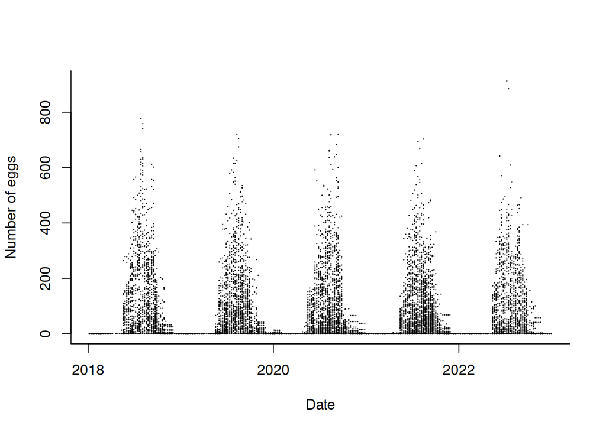

```r
plot(eggs~date,  data=mydf, cex=0.05 ,  xlab="Date", ylab="Number of eggs", bty="l")
```

```r
summary(mydf$eggs)
```

```
##    Min. 1st Qu.  Median    Mean 3rd Qu.    Max.    NA's
##    0.00    0.00    0.00   51.51   57.00  913.00    7588
```

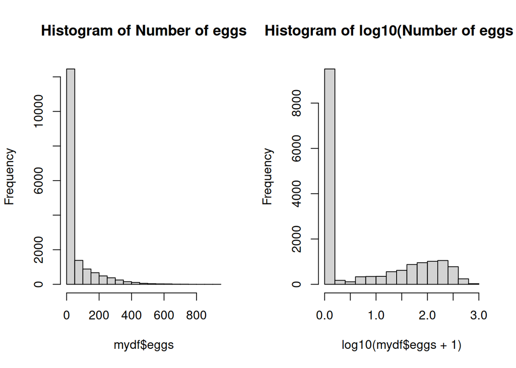

```r
par(mfrow=c(1,2))
hist(mydf$eggs, main = "Histogram of Number of eggs")
hist(log10(mydf$eggs + 1 ), main = "Histogram of log10(Number of eggs +1)")
```

```r
par(mfrow=c(1,1))
```

Inspect an individual time series ID_subset

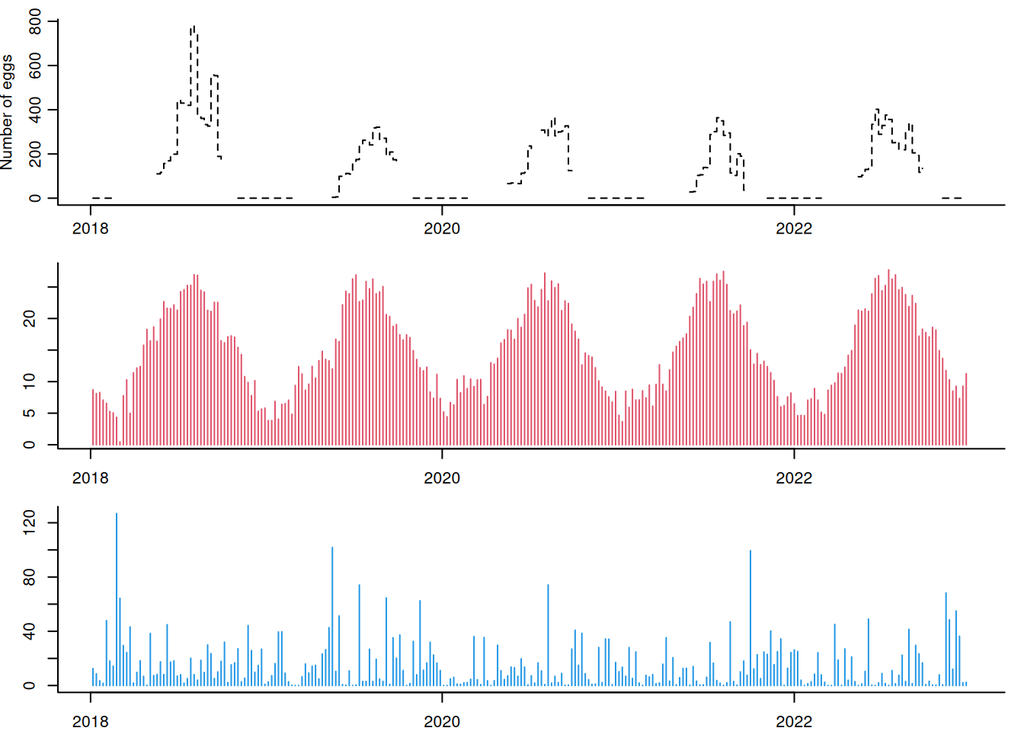

```r
ID_subset = "9347"

dsub <- subset(mydf, ID==ID_subset)

par(mar=c(2,3,1,1))
layout(matrix(1:3, nrow=3), heights=c(2,2,2))
plot(eggs~date, data=dsub, type="s", lty=2, bty="l", xlab="",
     ylab="Number of eggs", mgp=c(2.2,0.7,0), lab=c(5,3,7))
plot(medianTweek~date, data=dsub, type="h", lty=1, bty="l", col=2, xlab="",
     ylab="Temperature  (°C)")
plot(cumPrecweek~date, data=dsub, type="h", lty=1, bty="l", col=4, xlab="Date",
     ylab="Cumulative precipitation (mm)")
```

```r
layout(1)
par(mar=c(5,4,4,1)+0.1)
```

We apply log10 transformation to **brutally** account for the negative binomial distribution

```r
mydf$eggsL10<- log10(mydf$eggs+1)
```

Investigate the latitudinal variation

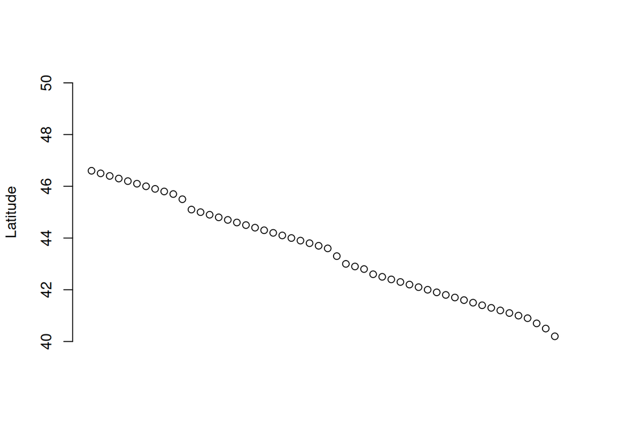

```r
plot(unique(mydf$lat), ylim=c(40,50), xaxt='n', xlab="", ylab="Latitude",  lty=1, bty="n")
```

## 2. Trend and Seasonality

Define spline transformation to capture the seasonal trends.

```r
# long interannual temporal trend
dftrend <- round(as.numeric(diff(range(mydf$date))/365.25 * length(unique(mydf$year))))
btrend <- ns(mydf$date, knots=equalknots(mydf$date, dftrend-1))
# seasonal intraannual trend
bseas <- ns(mydf$month, df=4) #week
```

Define the stratum as a grouping factor (so far, we’re not using it)

```r
mydf$stratum <- with(mydf, factor(Region))
```

## 3. Univariate models

### 3.1 Temperature

To model the delayed and potentially non-linear effect of temperature on egg abundance, we define a crossbasis using a Distributed Lag Non-Linear Model (DLNM) framework.

A B-spline is applied to the temperature dimension, with knots positioned at the lower and upper quartiles of the temperature distribution. This allows flexible modeling of the non-linear relationship between temperature and the response.

For the lag dimension, we consider effects up to 8 weeks. A spline is also used here, with knots placed at the 1st and 4th week, capturing both short- and medium-term lagged associations.

```r
tknots<-unname(quantile(mydf$medianTweek, probs = c(0.25, 0.75), na.rm = TRUE))
#original

cbTemp <- crossbasis(mydf$medianTweek, lag=8,
                     argvar=list(fun="bs", degree=2, knots=tknots),
                     arglag=list(knots=c(1,4)),
                     group=mydf$Region)
```

We now run the model suite, consisting of the following univariate configurations:

- **mod_T**: A univariate model including only temperature as the predictor, used to assess the direct effect of temperature on the response variable.
- **mod_T.seas**: A univariate model including both temperature and a seasonal component, to evaluate the temperature effect while accounting for underlying seasonal trends.
- **mod_T_pred**: A predictive univariate model including temperature, in which the crossbasis is pre-computed and passed as a separate data frame. This facilitates predictions on new data or for missing time points.

```r
# Fit mod_Tel to analyse coefficients
mod_T <- gnm(eggsL10 ~ cbTemp,
           #eliminate=stratum, #grouping factor
           data=mydf,
           family=gaussian(),
           na.action= "na.exclude")

mod_T.seas <- gnm(eggsL10 ~ cbTemp+ bseas, # + btrend,
           #eliminate=stratum, #grouping factor
           data=mydf,
           family=gaussian(),
           na.action= "na.exclude")

# define predictive model
cbTemp_df <- as.data.frame(cbTemp)
colnames(cbTemp_df) <- paste0("cb", seq_len(ncol(cbTemp_df)))

mydf_ext <- cbind(mydf, cbTemp_df)

# Build formula with those columns
form <- as.formula(paste("eggsL10 ~", paste(colnames(cbTemp_df), collapse = " + ")))

# Fit mod_Tel to predict on new data
mod_T_pred <- gnm(form,
                data = mydf_ext,
                family = gaussian(),
                na.action = "na.exclude")
bseas_df <- as.data.frame(bseas)
colnames(bseas_df) <- paste0("bt", seq_len(ncol(bseas_df)))
mydf_ext.seas <- cbind(mydf, cbTemp_df, bseas_df) #btrend

# Build formula with those columns
form <- as.formula(paste("eggsL10 ~", paste(colnames( cbind(cbTemp_df,  bseas_df)), collapse = " + "))) # btrend_df,

mod_T.seas_pred <- gnm(form,
                data = mydf_ext.seas,
                family = gaussian(),
                na.action = "na.exclude")
```

Inspect the AIC for the univariate model with temperature and the model with temperature and seasonality

```r
AIC(mod_T, mod_T.seas)
```

```
##            df      AIC
## mod_T      18 25021.13
## mod_T.seas 22 24852.98
```

#### 3.1.1 Response curves

Investigate the response curves on temperature.

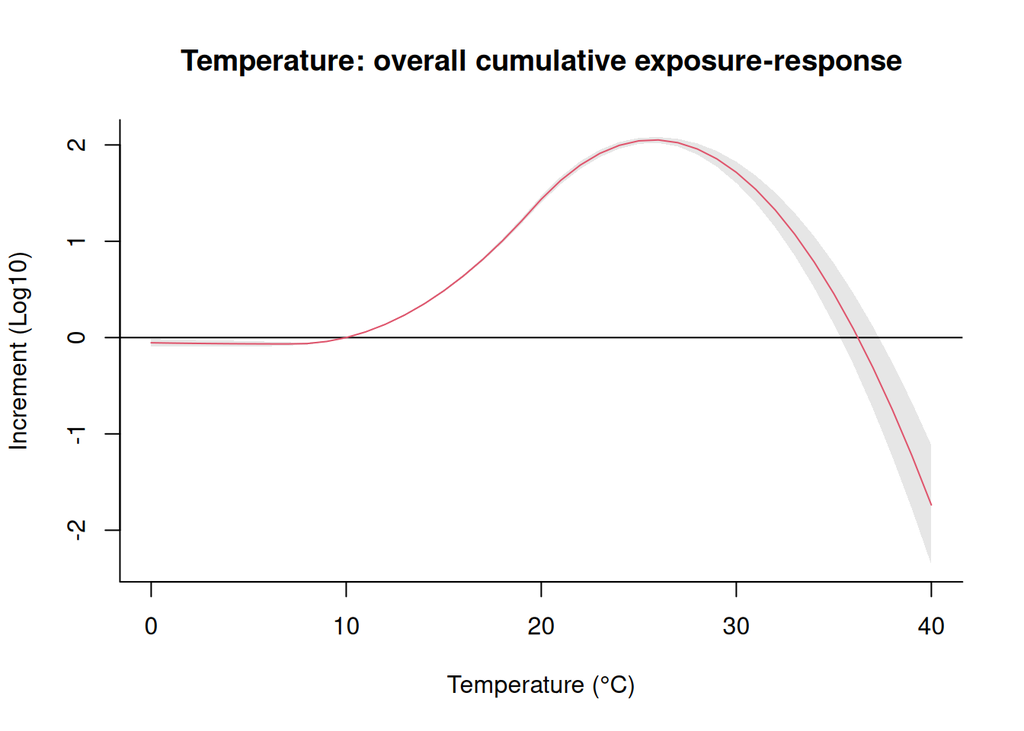

```r
#centering point at 10°C
myCen <- 10
cptmean <- crosspred(cbTemp, mod_T, cen=myCen, by=1, at=0:40)
cptmean.seas <- crosspred(cbTemp, mod_T.seas, cen=myCen, by=1, at=0:40)

# Overall cumulative
plot(cptmean, ptype="overall", xlab="Temperature (°C)", ylab="Increment (Log10)", col=2,
     main="Temperature: overall cumulative exposure-response")
```

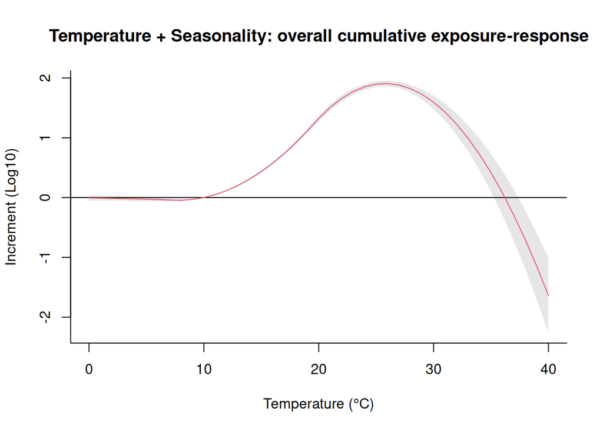

```r
plot(cptmean.seas, ptype="overall", xlab="Temperature (°C)", ylab="Increment (Log10)", col=2,
     main="Temperature + Seasonality: overall cumulative exposure-response")
```

Temperature and lags together

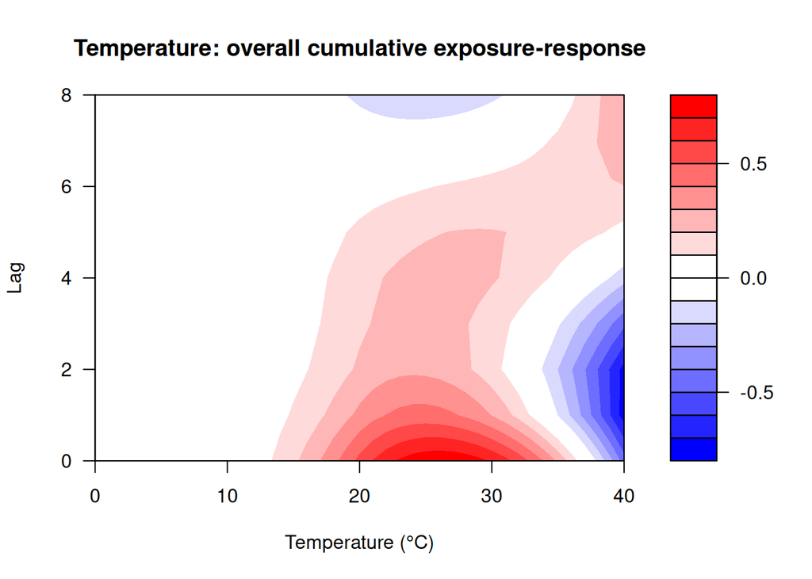

```r
# Contour map 2D
plot(cptmean, "contour", xlab="Temperature (°C)", ylab="Lag",
     main="Temperature: overall cumulative exposure-response")
```

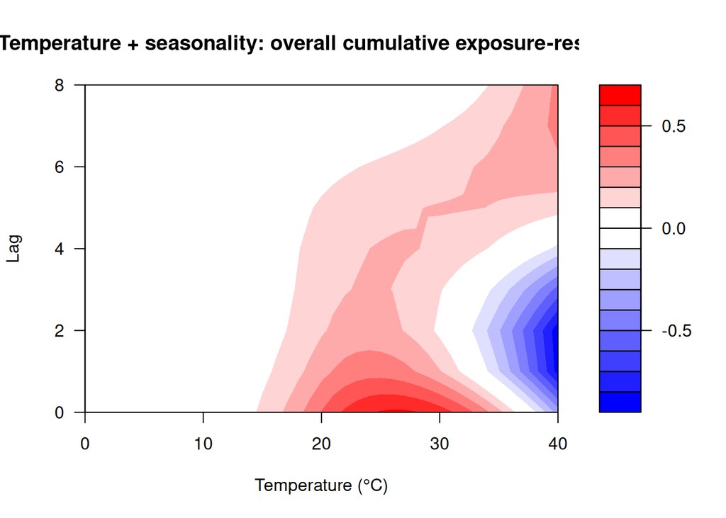

```r
plot(cptmean.seas, "contour", xlab="Temperature (°C)", ylab="Lag",
     main="Temperature + seasonality: overall cumulative exposure-response")
```

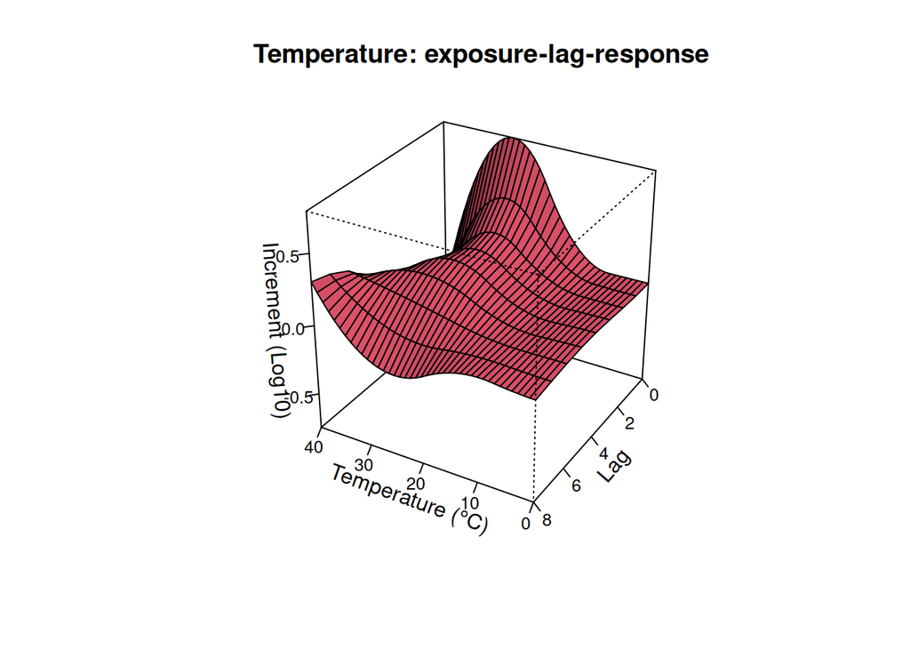

```r
# 3D surface
plot(cptmean, xlab="Temperature (°C)", zlab="Increment (Log10)",
     ltheta=240, lphi=60, cex.axis=0.8,
     main="Temperature: exposure-lag-response", col=2)
```

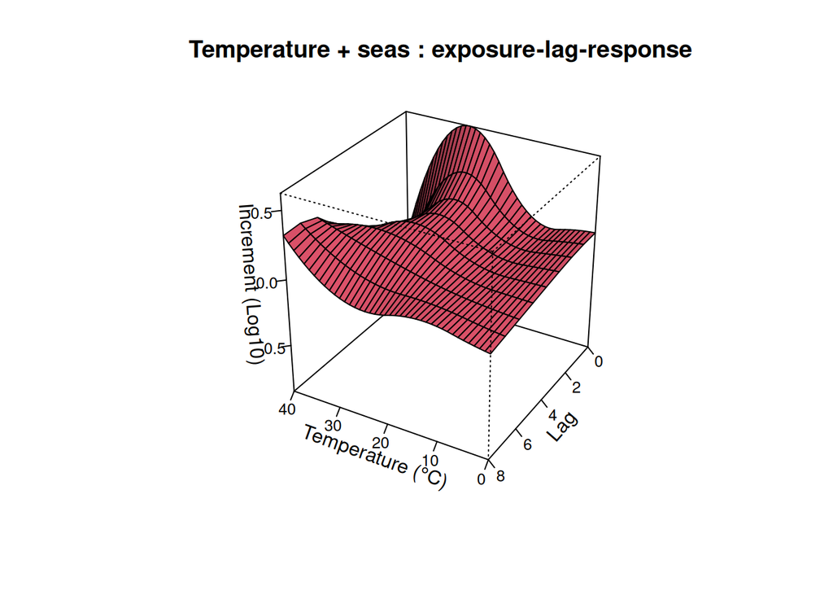

```r
plot(cptmean.seas, xlab="Temperature (°C)", zlab="Increment (Log10)",
     ltheta=240, lphi=60, cex.axis=0.8,
     main="Temperature + seas : exposure-lag-response", col=2)
```

Plot the effect at different lags (univariate model only)

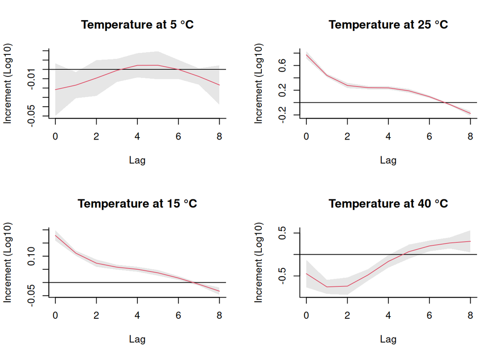

```r
layout(matrix(1:4, ncol=2, nrow = 2))
plot(cptmean, var=5, xlab="Lag", ylab="Increment (Log10)", col=2,
     main="Temperature at 5 °C")

plot(cptmean, var=15, xlab="Lag", ylab="Increment (Log10)", col=2,
     main="Temperature at 15 °C")

plot(cptmean, var=25, xlab="Lag", ylab="Increment (Log10)", col=2,
     main="Temperature at 25 °C")

plot(cptmean, var=40, xlab="Lag", ylab="Increment (Log10)", col=2,
     main="Temperature at 40 °C")
```

```r
layout(1)
```

Plot the effect at different Temperatures (univariate model only)

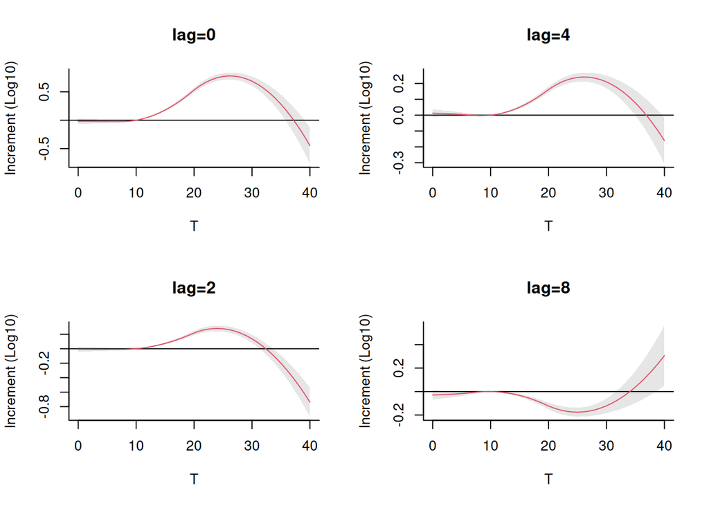

```r
layout(matrix(1:4, ncol=2, nrow = 2))
plot(cptmean, lag=0, xlab="T", ylab="Increment (Log10)", col=2,
     main="lag=0")

plot(cptmean, lag=2, xlab="T", ylab="Increment (Log10)", col=2,
     main="lag=2")

plot(cptmean, lag=4, xlab="T", ylab="Increment (Log10)", col=2,
     main="lag=4")

plot(cptmean, lag=8, xlab="T", ylab="Increment (Log10)", col=2,
     main="lag=8")
```

```r
layout(1)
```

#### 3.1.2 Plot fitted values

Plot values predicted on one random location selected from the calibration dataset.

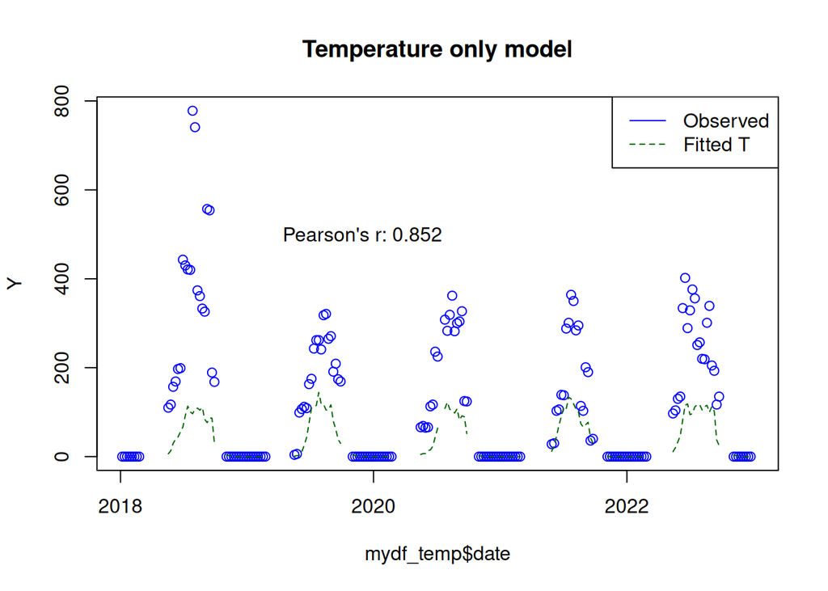

```r
mydf$fitted <- 10^(fitted(mod_T_pred))-1
mydf$fitted.seas <- 10^(fitted(mod_T.seas_pred))-1

mydf_temp <- mydf %>%
  filter(ID == ID_subset)

plot(mydf_temp$date, mydf_temp$eggs, type="p" ,col="blue", ylab="Y", main= "Temperature only model")
lines(mydf_temp$date, mydf_temp$fitted, col="darkgreen", lty=2)
legend("topright", legend=c("Observed", "Fitted T"), col=c("blue", "darkgreen"), lty=c(1,2))
text(x=mydf_temp$date[100],y=500, labels=paste("Pearson's r:", round(cor.test(mydf_temp$eggs, mydf_temp$fitted)$estimate,3)))
```

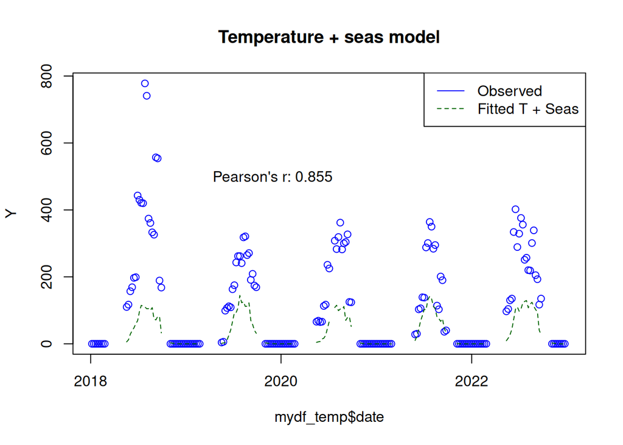

```r
plot(mydf_temp$date, mydf_temp$eggs, type="p" ,col="blue", ylab="Y", main= "Temperature + seas model")
lines(mydf_temp$date, mydf_temp$fitted.seas, col="darkgreen", lty=2)
legend("topright", legend=c("Observed", "Fitted T + Seas"), col=c("blue", "darkgreen"), lty=c(1,2))
text(x=mydf_temp$date[100],y=500, labels=paste("Pearson's r:", round(cor.test(mydf_temp$eggs, mydf_temp$fitted.seas)$estimate,3)))
```

#### 3.1.3 Validation plot

Plot values predicted on the location that was previously excluded from the model calibration.

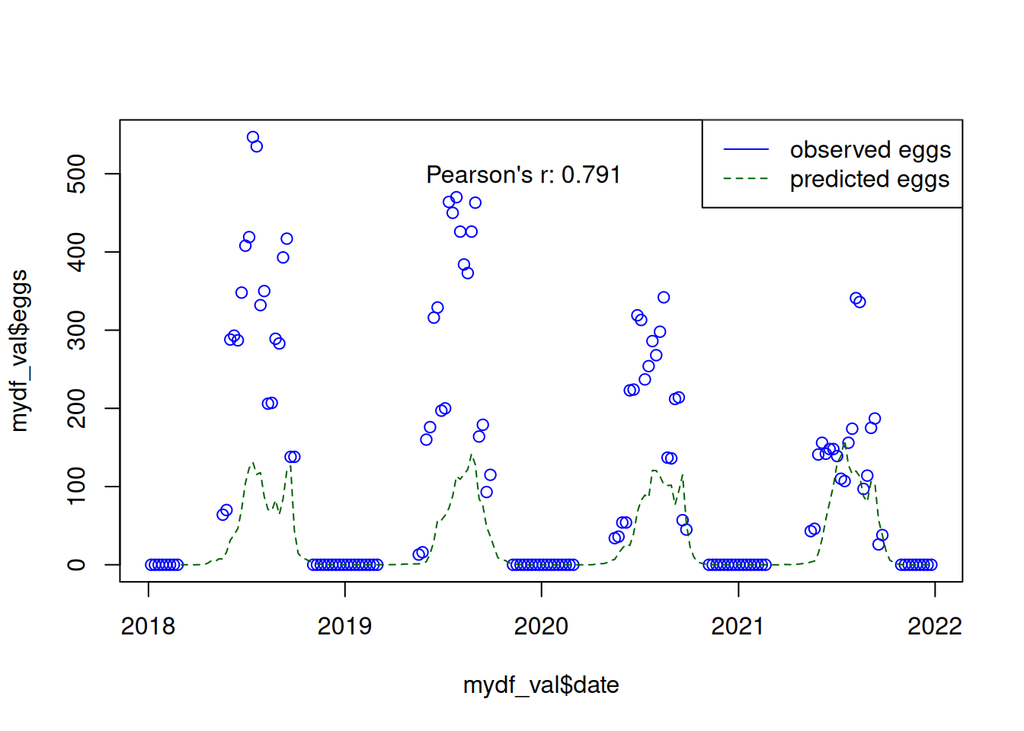

```r
mydf_val <- bio.matrix_sel %>%
  filter(ID == ID_val)

regions <- unique(mydf$Region)

# Build newdf with same shape as original (if needed)
newdf <- data.frame(date = mydf_val$date,
                    medianTweek = mydf_val$medianTweek)

# Build new crossbasis
cbTemp_val <- crossbasis(newdf$medianTweek, lag=8,
                     argvar=list(fun="bs", degree=2, knots=tknots),
                     arglag=list(knots=c(1,4)),
                     group=newdf$Region)

cbTemp_val_df <- as.data.frame(cbTemp_val)
colnames(cbTemp_val_df) <- paste0("cb", seq_len(ncol(cbTemp_val_df)))
newdf_ext <- cbind(newdf, cbTemp_val_df)

# Predict
log10eggsPred <- predict(mod_T_pred, newdata = newdf_ext, type = "response")
mydf_val$eggsPred  = 10^(log10eggsPred)-1

#plot
plot(mydf_val$date, mydf_val$eggs, col = "blue")
lines(newdf$date, mydf_val$eggsPred , col = "darkgreen", lty=2)
# plot(newdf$date, predY, col = "darkgreen")
legend("topright", legend=c("observed eggs", "predicted eggs"), col=c("blue", "darkgreen"), lty=c(1,2))
text(x=mydf_val$date[100],y=500, labels=paste("Pearson's r:", round(cor.test(mydf_val$eggs, mydf_val$eggsPred)$estimate,3)))
```

Predict also using the model with both Temperature and seasonality.

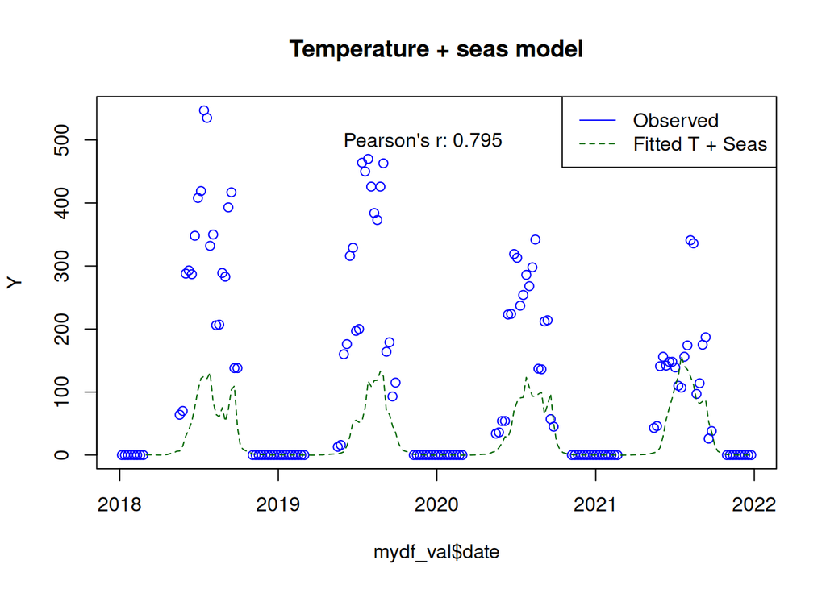

```r
# long interannual temporal trend
btrend <- ns(mydf_val$date, knots=equalknots(mydf_val$date, dftrend-1))
# seasonal intraannual trend
bseas_pred <- ns(mydf_val$month, df=4) #week

bseas_pred_df <- as.data.frame(bseas_pred)
colnames(bseas_pred_df) <- paste0("bt", seq_len(ncol(bseas_pred_df)))

mydf_ext.seas <- cbind(newdf, cbTemp_val_df, bseas_pred_df)

# Predict
log10eggsPred <- predict(mod_T.seas_pred, newdata = mydf_ext.seas, type = "response")
mydf_val$eggsPred_seas  = 10^(log10eggsPred)-1

# plot
plot(mydf_val$date, mydf_val$eggs, type="p" ,col="blue", ylab="Y", main= "Temperature + seas model")
lines(mydf_val$date, mydf_val$eggsPred_seas , col="darkgreen", lty=2)
legend("topright", legend=c("Observed", "Fitted T + Seas"), col=c("blue", "darkgreen"), lty=c(1,2))
text(x=mydf_val$date[100],y=500, labels=paste("Pearson's r:", round(cor.test(mydf_val$eggs, mydf_val$eggsPred_seas )$estimate,3)))
```

#### 3.1.4 Risk factors

```r
#Estimation at different T and lags
t.risk.v <- as.character(5*(0:(40/5)))

t.risk.df = data.frame(temp = t.risk.v,
                       allfit = NA,
                       alllow = NA,
                       allhigh = NA)

# can do it both with cptmean and cptmean.seas
for (t.risk in t.risk.v){
  t.risk.df[which(t.risk== t.risk.v),2:4] =
    round(with(cptmean.seas, cbind(allfit, alllow, allhigh)[t.risk,]), 2)
}

t.risk.df
```

```
##   temp allfit alllow allhigh
## 1    0  -0.01  -0.05    0.04
## 2    5  -0.03  -0.06    0.00
## 3   10   0.00   0.00    0.00
## 4   15   0.43   0.42    0.45
## 5   20   1.32   1.28    1.37
## 6   25   1.90   1.85    1.94
## 7   30   1.59   1.48    1.71
## 8   35   0.42   0.10    0.73
## 9   40  -1.64  -2.26   -1.01
```

```r
# lag.risk.v <- as.character(0:8)
#
# lag.risk.df = data.frame(lag = lag.risk.v,
#                        allfit = NA,
#                        alllow = NA,
#                        allhigh = NA)
#
# for (lag.risk in lag.risk.v){
#   lag.risk.df[which(lag.risk== lag.risk.v),2:4] =
#     round(with(cptmean, cbind(allfit, alllow, allhigh)[,lag.risk]), 2)
# }
```

### 3.2. Precipitation

To assess the delayed and non-linear effects of weekly cumulative precipitation on egg abundance, we define a crossbasis function using the Distributed Lag Non-Linear Model (DLNM) approach.

- For the exposure dimension (cumPrecweek), we apply a B-spline of degree 2 with knots placed at the 50th (median) and 90th percentiles of the precipitation distribution. This allows the model to flexibly capture non-linear relationships between precipitation and the response variable.
- For the lag dimension, we consider a maximum lag of 8 weeks, with internal knots at weeks 1 and 4. This structure captures both short-term and delayed effects.

```r
pknots<-unname(quantile(mydf$cumPrecweek, probs = c(0.5, 0.90), na.rm = TRUE))
#original
cbPrec <- crossbasis(mydf$cumPrecweek, lag=8,
                     argvar=list(fun="bs", degree=2, knots=pknots),
                     arglag=list(knots=c(1,4)),
                     group=mydf$Region)
```

We now run a series of univariate models to investigate the effect of precipitation on egg abundance. The model suite includes the following configurations:

- **mod_P**: A univariate model including only precipitation as the predictor, used to evaluate the direct effect of precipitation on the response variable.
- **mod_P.seas**: A univariate model including both precipitation and a seasonal component, allowing us to assess the precipitation effect while adjusting for seasonal patterns.
- **mod_P_pred**: A predictive univariate model including precipitation, where the crossbasis is pre-computed and passed as a separate data frame. This setup supports forecasting or imputing values in weeks with missing data.

```r
# Fit mod_Pel to analyse coefficients
mod_P <- gnm(eggsL10 ~ cbPrec,
             #eliminate=stratum, #grouping factor
             data=mydf,
             family=gaussian(),
             na.action= "na.exclude")

mod_P.seas <- gnm(eggsL10 ~ cbPrec+ bseas, # + btrend,
                  #eliminate=stratum, #grouping factor
                  data=mydf,
                  family=gaussian(),
                  na.action= "na.exclude")

# define predictive model
cbPrec_df <- as.data.frame(cbPrec)
colnames(cbPrec_df) <- paste0("cb", seq_len(ncol(cbPrec_df)))

mydf_ext <- cbind(mydf, cbPrec_df)

# Build formula with those columns
form <- as.formula(paste("eggsL10 ~", paste(colnames(cbPrec_df), collapse = " + ")))

# Fit mod_Pel to predict on new data
mod_P_pred <- gnm(form,
                  data = mydf_ext,
                  family = gaussian(),
                  na.action = "na.exclude")

bseas_df <- as.data.frame(bseas)
colnames(bseas_df) <- paste0("bt", seq_len(ncol(bseas_df)))
mydf_ext.seas <- cbind(mydf, cbPrec_df, bseas_df) #btrend

# Build formula with those columns
form <- as.formula(paste("eggsL10 ~", paste(colnames( cbind(cbPrec_df, bseas_df)), collapse = " + "))) # btrend_df,

mod_P.seas_pred <- gnm(form,
                       data = mydf_ext.seas,
                       family = gaussian(),
                       na.action = "na.exclude")
```

Inspect the AIC for the univariate model with precipitation and the model with precipitation and seasonality

```r
AIC(mod_P, mod_P.seas)
```

```
##            df      AIC
## mod_P      18 44022.04
## mod_P.seas 22 29152.20
```

#### 3.2.1 Response curves

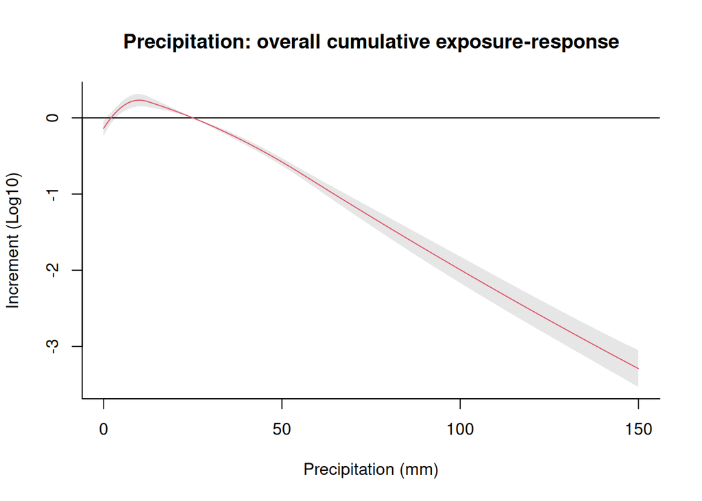

```r
#centering point at 25 mm
myCen <- 25
cppcum <- crosspred(cbPrec, mod_P, cen=myCen, by=1, at=0:150)
cppcum.seas <- crosspred(cbPrec, mod_P.seas, cen=myCen, by=1, at=0:150)

# Overall cumulative
plot(cppcum, ptype="overall", xlab="Precipitation (mm)", ylab="Increment (Log10)", col=2,
     main="Precipitation: overall cumulative exposure-response")
```

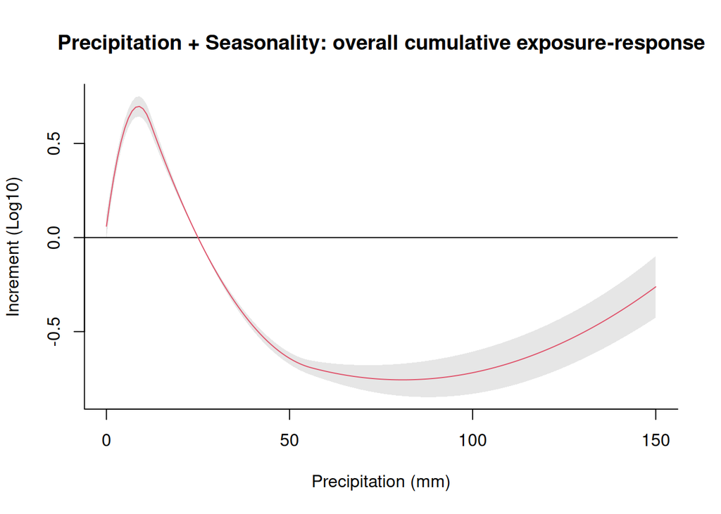

```r
plot(cppcum.seas, ptype="overall", xlab="Precipitation (mm)", ylab="Increment (Log10)", col=2,
     main="Precipitation + Seasonality: overall cumulative exposure-response")
```

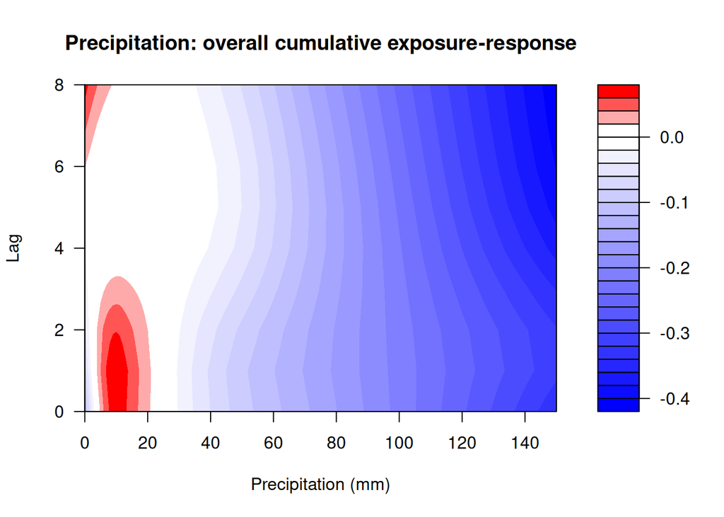

```r
# Contour map 2D
plot(cppcum, "contour", xlab="Precipitation (mm)", ylab="Lag",
     main="Precipitation: overall cumulative exposure-response")
```

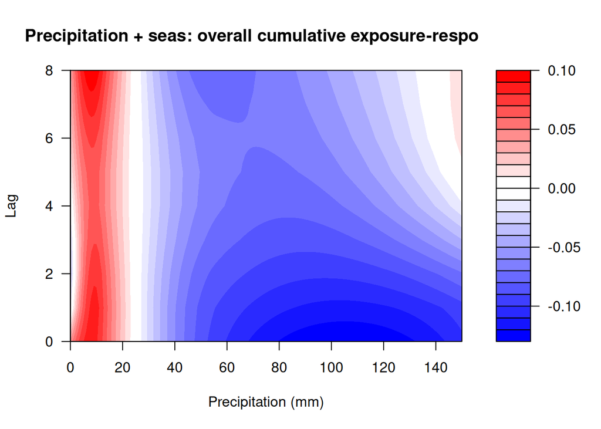

```r
plot(cppcum.seas, "contour", xlab="Precipitation (mm)", ylab="Lag",
     main="Precipitation + seas: overall cumulative exposure-response")
```

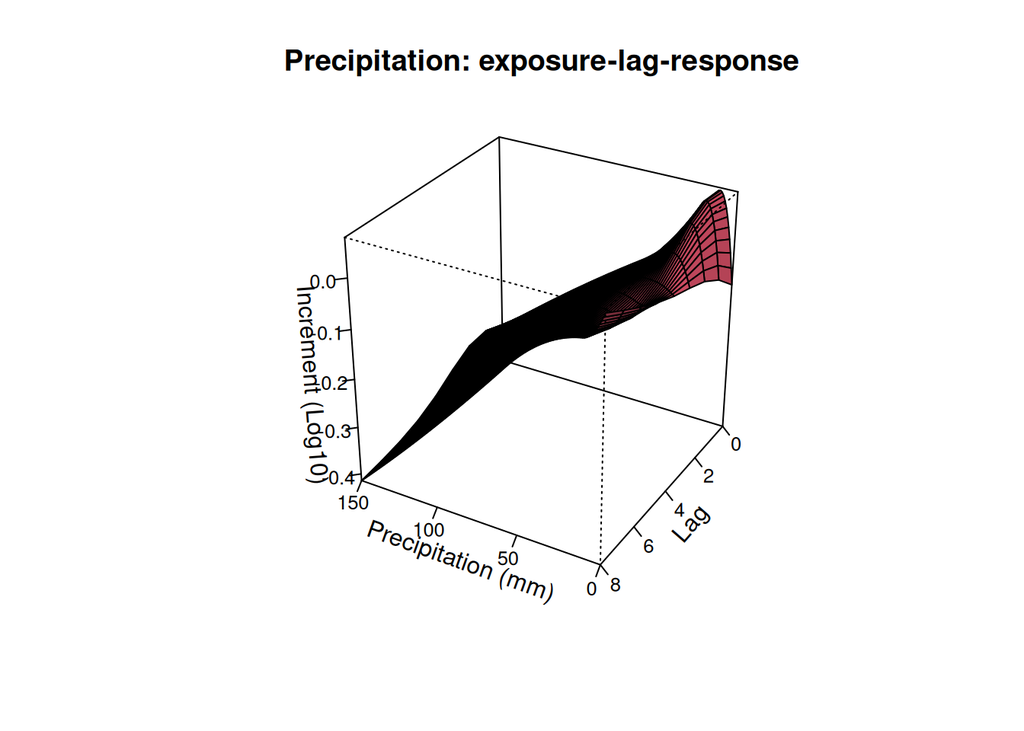

```r
# 3D surface
plot(cppcum, xlab="Precipitation (mm)", zlab="Increment (Log10)",
     ltheta=240, lphi=60, cex.axis=0.8,
     main="Precipitation: exposure-lag-response", col=2)
```

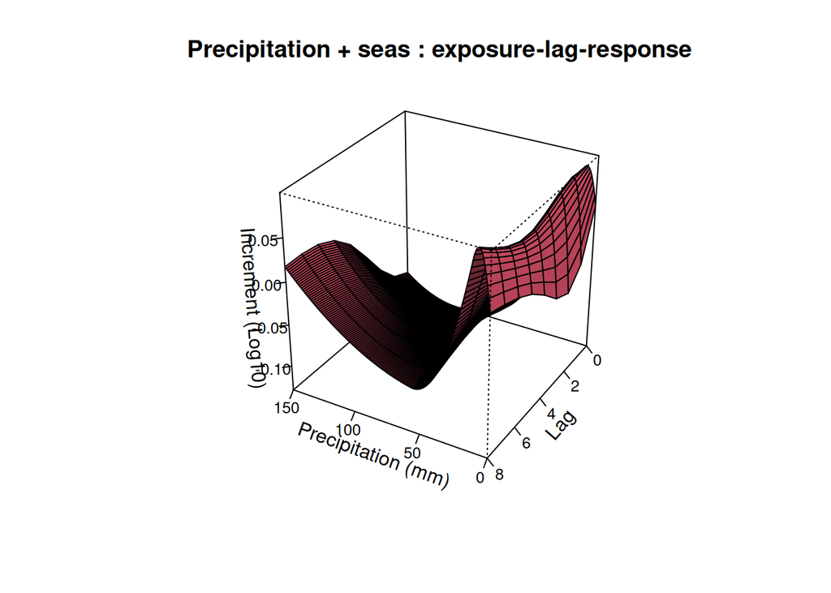

```r
plot(cppcum.seas, xlab="Precipitation (mm)", zlab="Increment (Log10)",
     ltheta=240, lphi=60, cex.axis=0.8,
     main="Precipitation + seas : exposure-lag-response", col=2)
```

Plot the effect at different lags

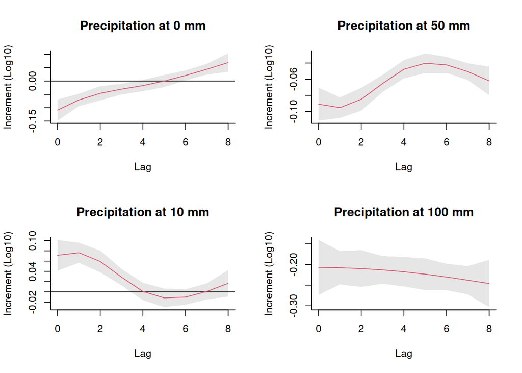

```r
layout(matrix(1:4, ncol=2, nrow = 2))
plot(cppcum, var=0, xlab="Lag", ylab="Increment (Log10)", col=2,
     main="Precipitation at 0 mm")

plot(cppcum, var=10, xlab="Lag", ylab="Increment (Log10)", col=2,
     main="Precipitation at 10 mm")

plot(cppcum, var=50, xlab="Lag", ylab="Increment (Log10)", col=2,
     main="Precipitation at 50 mm")

plot(cppcum, var=100, xlab="Lag", ylab="Increment (Log10)", col=2,
     main="Precipitation at 100 mm")
```

```r
layout(1)
```

Plot the effect at different precipitation values

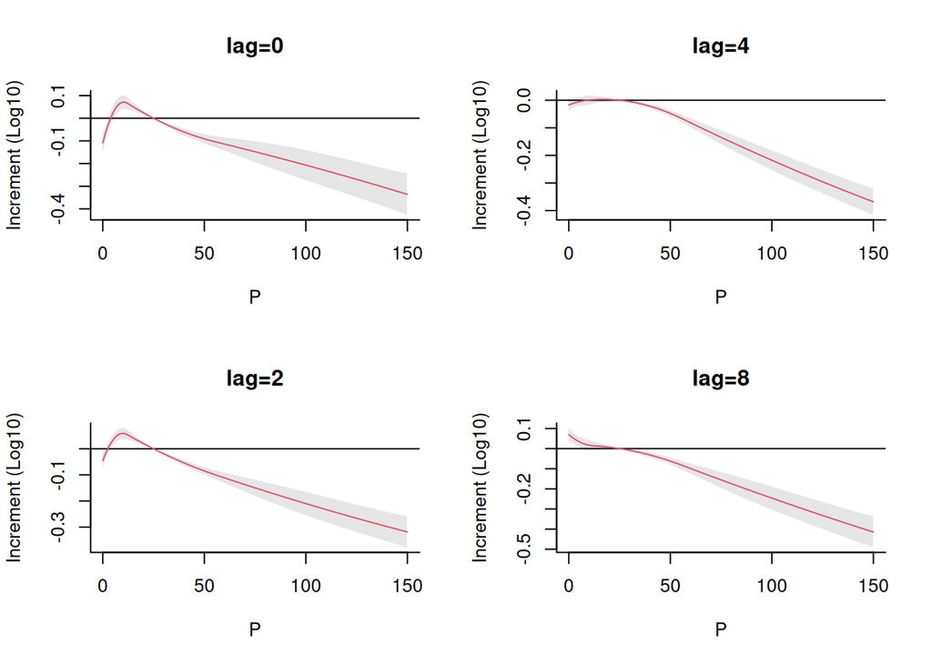

```r
layout(matrix(1:4, ncol=2, nrow = 2))
plot(cppcum, lag=0, xlab="P", ylab="Increment (Log10)", col=2,
     main="lag=0")

plot(cppcum, lag=2, xlab="P", ylab="Increment (Log10)", col=2,
     main="lag=2")

plot(cppcum, lag=4, xlab="P", ylab="Increment (Log10)", col=2,
     main="lag=4")

plot(cppcum, lag=8, xlab="P", ylab="Increment (Log10)", col=2,
     main="lag=8")
```

```r
layout(1)
```

#### 3.2.2 Plot fitted values

Plot values predicted on one random location selected from the calibration dataset.

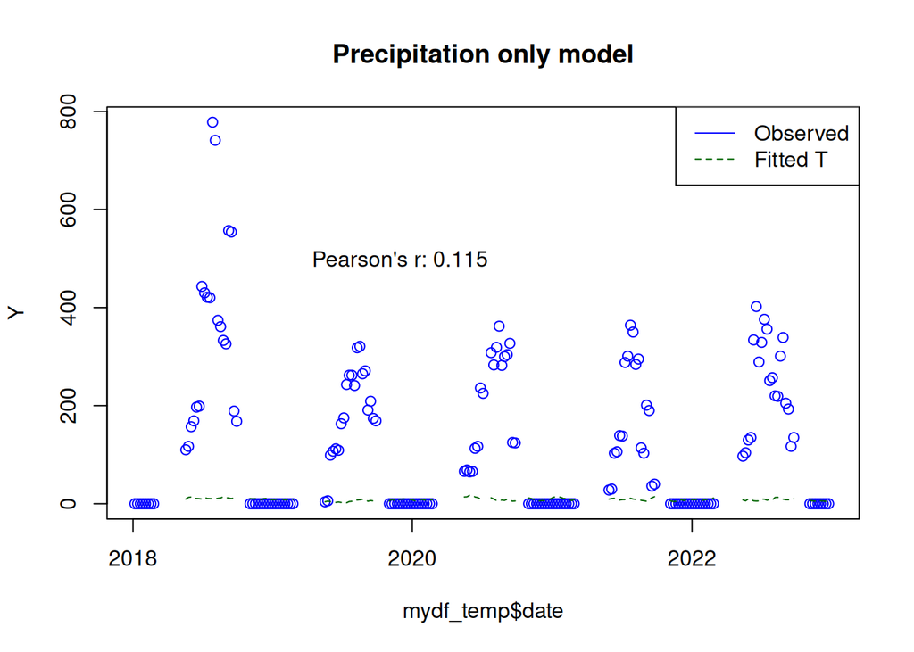

```r
mydf$fitted <- 10^(fitted(mod_P_pred))-1
mydf$fitted.seas <- 10^(fitted(mod_P.seas_pred))-1

mydf_temp <- mydf %>%
  filter(ID == ID_subset)

plot(mydf_temp$date, mydf_temp$eggs, type="p" ,col="blue", ylab="Y", main= "Precipitation only model")
lines(mydf_temp$date, mydf_temp$fitted, col="darkgreen", lty=2)
legend("topright", legend=c("Observed", "Fitted T"), col=c("blue", "darkgreen"), lty=c(1,2))
text(x=mydf_temp$date[100],y=500, labels=paste("Pearson's r:", round(cor.test(mydf_temp$eggs, mydf_temp$fitted)$estimate,3)))
```

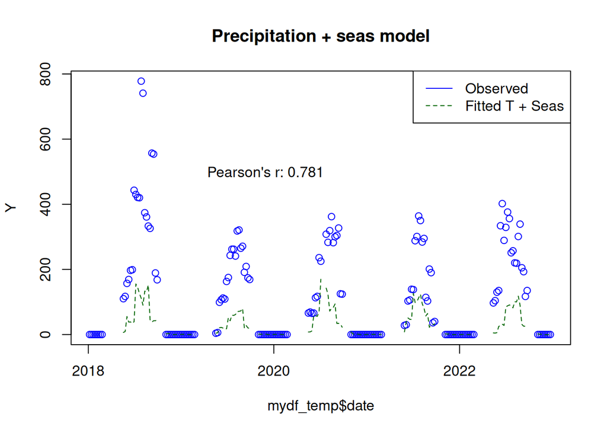

```r
plot(mydf_temp$date, mydf_temp$eggs, type="p" ,col="blue", ylab="Y", main= "Precipitation + seas model")
lines(mydf_temp$date, mydf_temp$fitted.seas, col="darkgreen", lty=2)
legend("topright", legend=c("Observed", "Fitted T + Seas"), col=c("blue", "darkgreen"), lty=c(1,2))
text(x=mydf_temp$date[100],y=500, labels=paste("Pearson's r:", round(cor.test(mydf_temp$eggs, mydf_temp$fitted.seas)$estimate,3)))
```

#### 3.2.3 Validation plot

Plot values predicted on the location that was previously excluded from the model calibration.

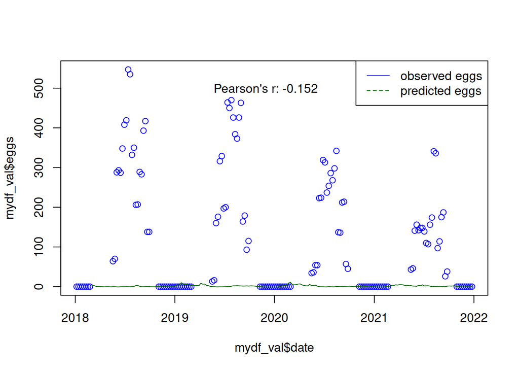

```r
mydf_val <- bio.matrix_sel %>%
  filter(ID == ID_val)

regions <- unique(mydf$Region)

# Build newdf with same shape as original (if needed)
newdf <- data.frame(date = mydf_val$date,
                    cumPrecweek = mydf_val$cumPrecweek)

# Build new crossbasis
cbPrec_val <- crossbasis(newdf$cumPrecweek, lag=8,
                         argvar=list(fun="bs", degree=2, knots=tknots),
                         arglag=list(knots=c(1,4)),
                         group=newdf$Region)

cbPrec_val_df <- as.data.frame(cbPrec_val)
colnames(cbPrec_val_df) <- paste0("cb", seq_len(ncol(cbPrec_val_df)))
newdf_ext <- cbind(newdf, cbPrec_val_df)

# Predict
log10eggsPred <- predict(mod_P_pred, newdata = newdf_ext, type = "response")
mydf_val$eggsPred  = 10^(log10eggsPred)-1

plot(mydf_val$date, mydf_val$eggs, col = "blue")
lines(newdf$date, mydf_val$eggsPred , col = "darkgreen")
# plot(newdf$date, predY, col = "darkgreen")
legend("topright", legend=c("observed eggs", "predicted eggs"), col=c("blue", "darkgreen"), lty=c(1,2))
text(x=mydf_val$date[100],y=500, labels=paste("Pearson's r:", round(cor.test(mydf_val$eggs, mydf_val$eggsPred)$estimate,3)))
```

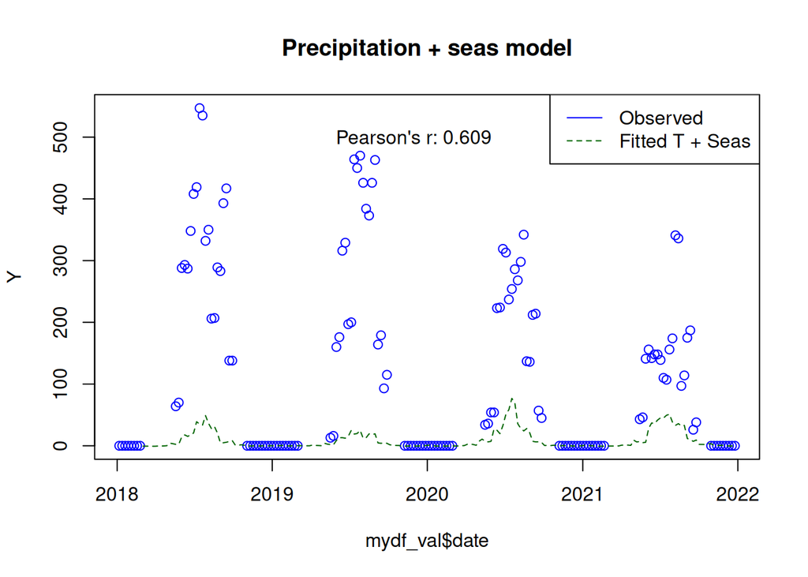

```r
# long interannual temporal trend
btrend <- ns(mydf_val$date, knots=equalknots(mydf_val$date, dftrend-1))
# seasonal intraannual trend
bseas_pred <- ns(mydf_val$month, df=4) #week

bseas_pred_df <- as.data.frame(bseas_pred)
colnames(bseas_pred_df) <- paste0("bt", seq_len(ncol(bseas_pred_df)))

mydf_ext.seas <- cbind(newdf, cbPrec_val_df, bseas_pred_df)

# Predict ()
log10eggsPred <- predict(mod_P.seas_pred, newdata = mydf_ext.seas, type = "response")
mydf_val$eggsPred_seas  = 10^(log10eggsPred)-1

#plot
plot(mydf_val$date, mydf_val$eggs, type="p" ,col="blue", ylab="Y", main= "Precipitation + seas model")
lines(mydf_val$date, mydf_val$eggsPred_seas , col="darkgreen", lty=2)
legend("topright", legend=c("Observed", "Fitted T + Seas"), col=c("blue", "darkgreen"), lty=c(1,2))
text(x=mydf_val$date[100],y=500, labels=paste("Pearson's r:", round(cor.test(mydf_val$eggs, mydf_val$eggsPred_seas )$estimate,3)))
```

#### 3.2.4 Risk factors

```r
#Estimation at different T and lags
p.risk.v <- as.character(c(0, 10, 20, 40, 60, 90, 120))
p.risk.df = data.frame(prec = p.risk.v,
                       allfit = NA,
                       alllow = NA,
                       allhigh = NA)

# can do it both with cppcum and cppcum.seas
for (p.risk in p.risk.v){
  p.risk.df[which(p.risk== p.risk.v),2:4] =
    round(with(cppcum.seas, cbind(allfit, alllow, allhigh)[p.risk,]), 2)
}
p.risk.df
```

```
##   prec allfit alllow allhigh
## 1    0   0.06   0.00    0.12
## 2   10   0.68   0.63    0.74
## 3   20   0.21   0.20    0.23
## 4   40  -0.47  -0.49   -0.44
## 5   60  -0.71  -0.76   -0.67
## 6   90  -0.75  -0.85   -0.65
## 7  120  -0.60  -0.73   -0.47
```

## 4. Mutivariate model

To jointly assess the effects of temperature and precipitation on egg abundance, we implement a set of multivariate models using crossbasis functions for both predictors.

- **mod_TP**: A multivariate model including both temperature (cbTemp) and precipitation (cbPrec) as predictors. This model evaluates the combined and independent effects of the two climatic variables on the response variable (eggsL10).
- **mod_TP.seas**: An extended version of the multivariate model that also includes a seasonal component (bseas). This allows us to disentangle the climatic effects from seasonal patterns in egg abundance.
- **mod_TP_pred**: A predictive multivariate model, where the crossbasis is pre-computed and passed as a separate data frame. This setup supports forecasting or imputing values in weeks with missing data.

```r
# Fit mod_Tel to analyse coefficients
mod_TP <- gnm(eggsL10 ~  cbTemp + cbPrec,
           #eliminate=stratum, #grouping factor
           data=mydf,
           family=gaussian(),
           na.action= "na.exclude")

mod_TP.seas <- gnm(eggsL10 ~ cbTemp + cbPrec + bseas, # + btrend,
           #eliminate=stratum, #grouping factor
           data=mydf,
           family=gaussian(),
           na.action= "na.exclude")

# define predictive model
cbTemp_df <- as.data.frame(cbTemp)
cbPrec_df <- as.data.frame(cbPrec)
colnames(cbTemp_df) <- paste0("cbT", seq_len(ncol(cbTemp_df)))
colnames(cbPrec_df) <- paste0("cbP", seq_len(ncol(cbPrec_df)))

cbTempPrec_df <- cbind(cbTemp_df, cbPrec_df)
mydf_ext <- cbind(mydf, cbTempPrec_df)

# Build formula with those columns
form <- as.formula(paste("eggsL10 ~", paste(colnames(cbTempPrec_df), collapse = " + ")))

# Fit mod_Tel to predict on new data
mod_TP_pred <- gnm(form,
                data = mydf_ext,
                family = gaussian(),
                na.action = "na.exclude")

bseas_df <- as.data.frame(bseas)
colnames(bseas_df) <- paste0("bt", seq_len(ncol(bseas_df)))
mydf_ext.seas <- cbind(mydf, cbTempPrec_df, bseas_df) #btrend

# Build formula with those columns
form <- as.formula(paste("eggsL10 ~", paste(colnames( cbind(cbTempPrec_df ,  bseas_df)), collapse = " + "))) # btrend_df,

mod_TP.seas_pred <- gnm(form,
                data = mydf_ext.seas,
                family = gaussian(),
                na.action = "na.exclude")
```

Investigate the AIC on all the model produced so far:

```r
data.frame( models = c("Temperature", "Temperature + seasonality", "Precipitation",  "Precipitation + seasonality", "Temperature + Precipitation", "Temperature + Precipitation + seasonality"),
            AIC =AIC(mod_T, mod_T.seas, mod_P, mod_P.seas, mod_TP, mod_TP.seas) )
```

```
##                                                models AIC.df  AIC.AIC
## mod_T                                     Temperature     18 25021.13
## mod_T.seas                  Temperature + seasonality     22 24852.98
## mod_P                                   Precipitation     18 44022.04
## mod_P.seas                Precipitation + seasonality     22 29152.20
## mod_TP                    Temperature + Precipitation     34 24123.20
## mod_TP.seas Temperature + Precipitation + seasonality     38 24045.78
```

### 4.1 response curves: temperatures

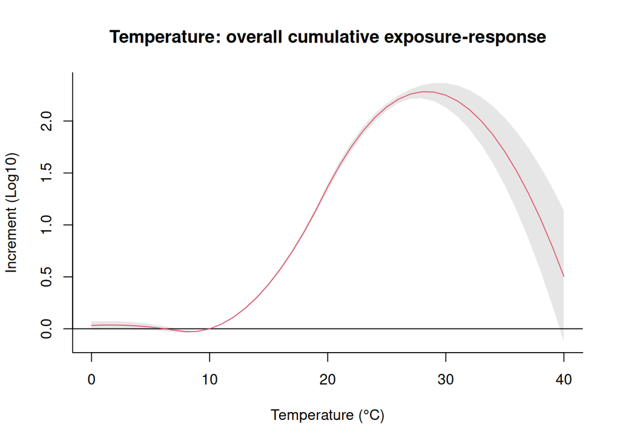

```r
#centering point at 10°C
myCen <- 10
cptmean <- crosspred(cbTemp, mod_TP, cen=myCen, by=1, at=0:40)
cptmean.seas <- crosspred(cbTemp, mod_TP.seas, cen=myCen, by=1, at=0:40)

# Overall cumulative
plot(cptmean, ptype="overall", xlab="Temperature (°C)", ylab="Increment (Log10)", col=2,
     main="Temperature: overall cumulative exposure-response")
```

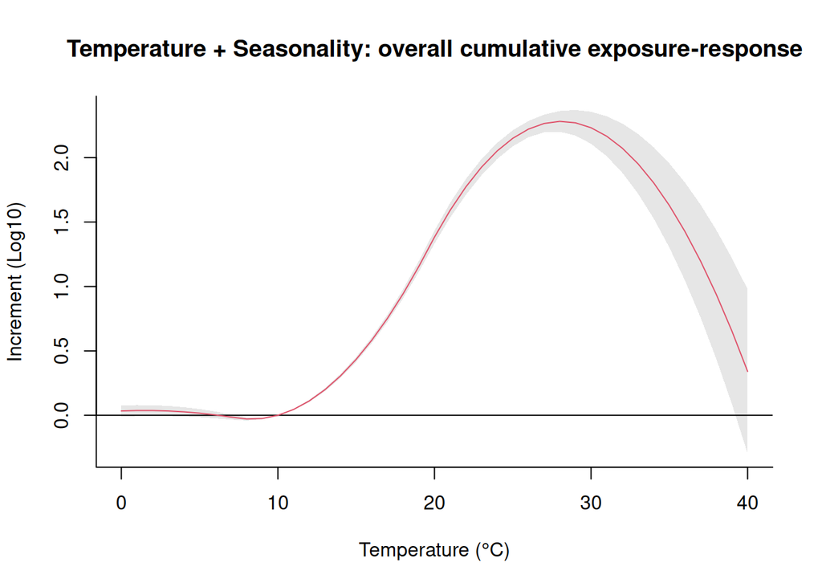

```r
plot(cptmean.seas, ptype="overall", xlab="Temperature (°C)", ylab="Increment (Log10)", col=2,
     main="Temperature + Seasonality: overall cumulative exposure-response")
```

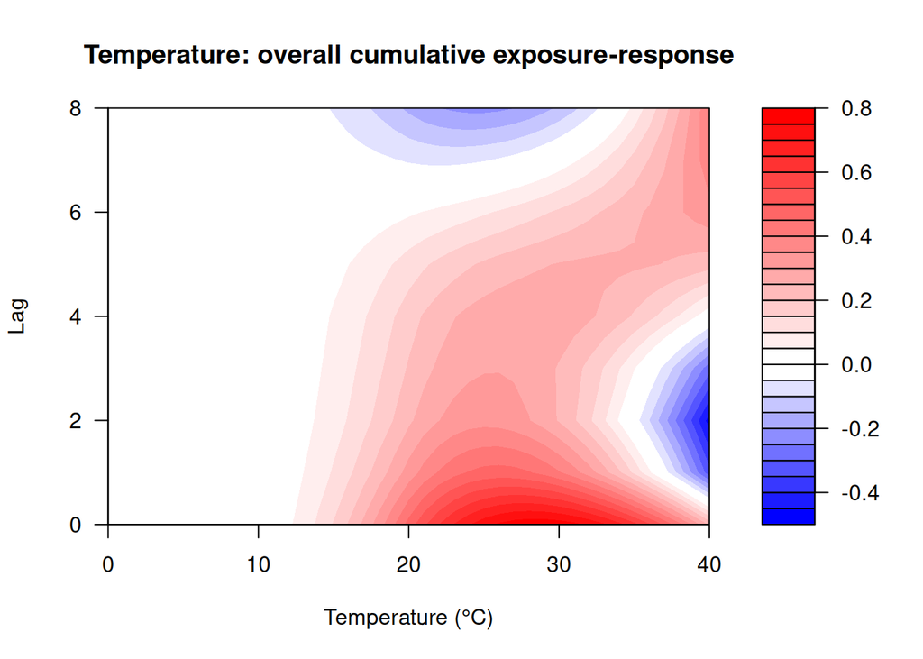

```r
# Contour map 2D
plot(cptmean, "contour", xlab="Temperature (°C)", ylab="Lag",
     main="Temperature: overall cumulative exposure-response")
```

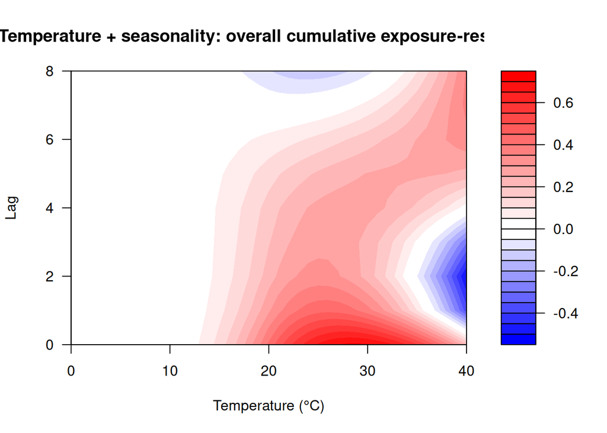

```r
plot(cptmean.seas, "contour", xlab="Temperature (°C)", ylab="Lag",
     main="Temperature + seasonality: overall cumulative exposure-response")
```